# Real-World Machine Learning

Chapter 3

Paul Adamson

December 7, 2016

This file contains R code to accompany Chapter 3 of the book [“Real-World Machine Learning”](https://www.manning.com/books/real-world-machine-learning), by Henrik Brink, Joseph W. Richards, and Mark Fetherolf. The code was contributed by [Paul Adamson](http://github.com/padamson).

*NOTE: working directory should be set to this file’s location.*

## Figure 3.4 A subset of the Titanic Passengers dataset

We are going to be interested in predicting survival, so it is useful to specify the `Survived` variable to be of type `factor`. For visualizing the data, it is also useful to use the `revalue` function to specify the `no` and `yes` levels for the `factor` variable. The `kable` function is built into the `knitr` package.

```r
titanic <- read.csv("../data/titanic.csv",
                    colClasses = c(
                      Survived = "factor",
                      Name = "character",
                      Ticket = "character",
                      Cabin = "character"))
titanic$Survived <- revalue(titanic$Survived, c("0"="no", "1"="yes"))
kable(head(titanic, 6), digits=2)
```

| PassengerId | Survived | Pclass | Name | Sex | Age | SibSp | Parch | Ticket | Fare | Cabin | Embarked |
| --- | --- | --- | --- | --- | --- | --- | --- | --- | --- | --- | --- |
| 1 | no | 3 | Braund, Mr. Owen Harris | male | 22 | 1 | 0 | A/5 21171 | 7.25 |  | S |
| 2 | yes | 1 | Cumings, Mrs. John Bradley (Florence Briggs Thayer) | female | 38 | 1 | 0 | PC 17599 | 71.28 | C85 | C |
| 3 | yes | 3 | Heikkinen, Miss. Laina | female | 26 | 0 | 0 | STON/O2. 3101282 | 7.92 |  | S |
| 4 | yes | 1 | Futrelle, Mrs. Jacques Heath (Lily May Peel) | female | 35 | 1 | 0 | 113803 | 53.10 | C123 | S |
| 5 | no | 3 | Allen, Mr. William Henry | male | 35 | 0 | 0 | 373450 | 8.05 |  | S |
| 6 | no | 3 | Moran, Mr. James | male | NA | 0 | 0 | 330877 | 8.46 |  | Q |

## Figure 3.5 Mosaic plot for Titanic data: Gender vs. survival

The [“Visualizing Categorical Data” package (`vcd`)](https://cran.r-project.org/web/packages/vcd/vcd.pdf) provides an excellent set of functions for exploring categorical data, including mosaic plots.

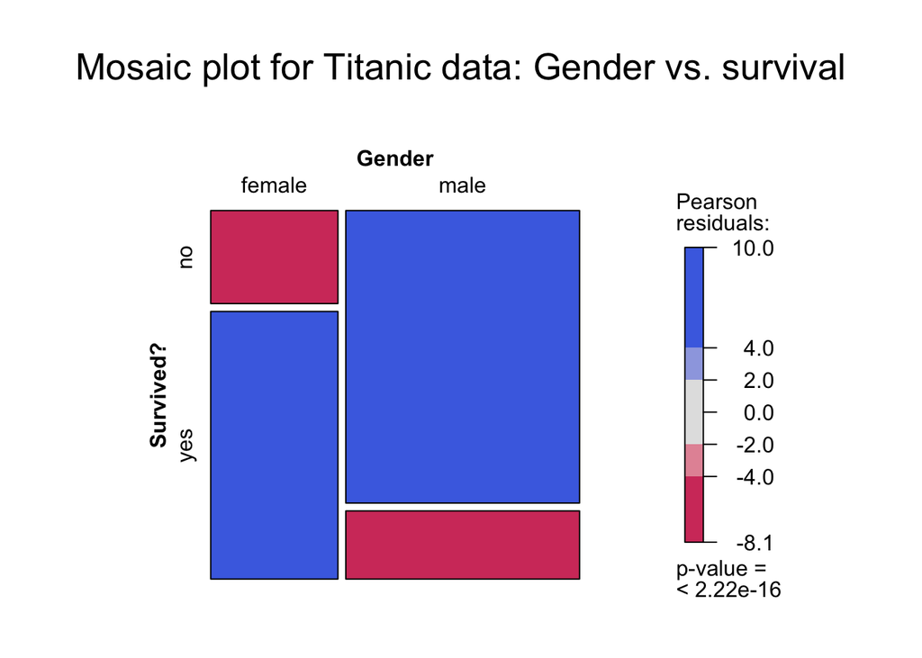

```r
mosaic(
  ~ Sex + Survived,
  data = titanic,
  main = "Mosaic plot for Titanic data: Gender vs. survival",
  shade = TRUE,
  split_vertical = TRUE,
  labeling_args = list(
    set_varnames = c(
      Survived = "Survived?",
      Sex = "Gender")))
```

## Figure 3.6 Processed data

First, we get rid of the variables that we do not want in our model. (`Cabin` might actually be useful, but it’s not used here.) Then we use `is.na` to set missing age values to -1. The `mutate` and `select` functions make it easy to take square root of the `Fare` variable and then drop it from the dataset. We then drop rows with missing `Embarked` data and remove the unused level `""`. Finally, we convert `factor` variables to dummy variables using the `dummyVars` function in the `caret` package. To avoid perfect collinearity (a.k.a. the dummy variable trap), we set the `fullRank` parameter to `TRUE`. `Survived.yes` is then converted back to a `factor` variable.

```r
titanicTidy <- subset(titanic, select = -c(PassengerId, Name, Ticket, Cabin))

titanicTidy$Age[is.na(titanicTidy$Age)] <- -1

titanicTidy <- titanicTidy %>%
  mutate(sqrtFare = sqrt(Fare)) %>%
  select(-Fare)

titanicTidy <- titanicTidy %>%
  filter(!(Embarked=="")) %>%
  droplevels

dummies <- dummyVars(" ~ .", data = titanicTidy, fullRank = TRUE)
titanicTidyNumeric <- data.frame(predict(dummies, newdata = titanicTidy))

titanicTidyNumeric$Survived.yes <- factor(titanicTidyNumeric$Survived.yes)
kable(head(titanicTidyNumeric))
```

| Survived.yes | Pclass | Sex.male | Age | SibSp | Parch | Embarked.Q | Embarked.S | sqrtFare |
| --- | --- | --- | --- | --- | --- | --- | --- | --- |
| 0 | 3 | 1 | 22 | 1 | 0 | 0 | 1 | 2.692582 |
| 1 | 1 | 0 | 38 | 1 | 0 | 0 | 0 | 8.442944 |
| 1 | 3 | 0 | 26 | 0 | 0 | 0 | 1 | 2.815138 |
| 1 | 1 | 0 | 35 | 1 | 0 | 0 | 1 | 7.286975 |
| 0 | 3 | 1 | 35 | 0 | 0 | 0 | 1 | 2.837252 |
| 0 | 3 | 1 | -1 | 0 | 0 | 1 | 0 | 2.908316 |

## Figure 3.10 Four randomly chosen handwritten digits from the MNIST database

Thanks to [Longhow Lam](https://longhowlam.wordpress.com/2015/11/25/a-little-h2o-deeplearning-experiment-on-the-mnist-data-set/) for posting the code used in the `displayMnistSamples` function that display’s digits from the MNIST dataset.

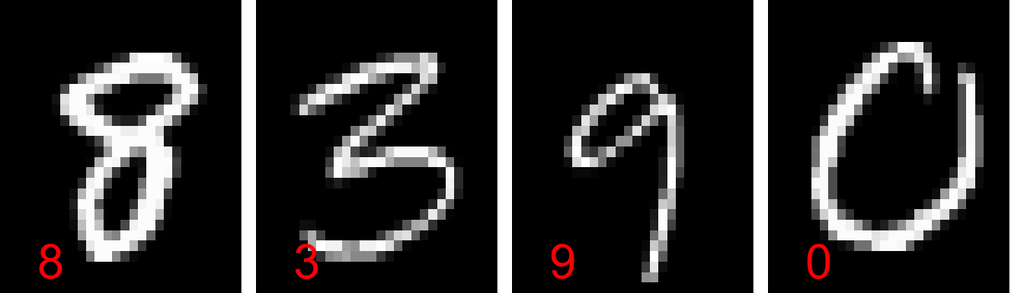

```r
mnist <- read.csv("../data/mnist_small.csv",
                  colClasses = c(label = "factor"))
displayMnistSamples <- function(x) {
  for(i in x){
  y = as.matrix(mnist[i, 2:785])
  dim(y) = c(28, 28)
  image( y[,nrow(y):1], axes = FALSE, col = gray(0:255 / 255))
  text( 0.2, 0, mnist[i,1], cex = 3, col = 2, pos = c(3,4))
  }
}
par( mfrow = c(1,4), mai = c(0,0,0,0.1))
displayMnistSamples(sample(1:length(mnist),4))
```

## Figure 3.11 Table of predicted probabilities from a k-nearest neighbors classifier, as applied to the MNIST dataset

```r
trainIndex <- createDataPartition(mnist$label, p = .8,
                                  list = FALSE,
                                  times = 1)
mnistTrain <- mnist[ trainIndex,]
mnistTest  <- mnist[-trainIndex,]

mnist.kknn <- kknn(label~., mnistTrain, mnistTest, distance = 1,
                   kernel = "triangular")

confusionMatrix(fitted(mnist.kknn),mnistTest$label)
```

```
## Confusion Matrix and Statistics
##
##           Reference
## Prediction  0  1  2  3  4  5  6  7  8  9
##          0 20  0  1  0  0  0  1  0  0  0
##          1  0 19  2  0  0  1  0  0  2  1
##          2  0  0 20  0  0  0  0  0  0  0
##          3  0  0  0 16  0  0  0  0  3  0
##          4  0  0  0  0 12  0  1  0  1  2
##          5  0  0  0  1  0 14  2  0  0  0
##          6  1  0  0  0  1  1 15  0  1  0
##          7  0  0  0  1  0  0  0 18  0  3
##          8  0  0  1  0  0  0  0  0 11  0
##          9  0  0  0  0  7  1  0  3  0 13
##
## Overall Statistics
##
##                Accuracy : 0.8061
##                  95% CI : (0.7437, 0.859)
##     No Information Rate : 0.1224
##     P-Value [Acc > NIR] : < 2.2e-16
##
##                   Kappa : 0.7844
##  Mcnemar's Test P-Value : NA
##
## Statistics by Class:
##
##                      Class: 0 Class: 1 Class: 2 Class: 3 Class: 4 Class: 5
## Sensitivity            0.9524  1.00000   0.8333  0.88889  0.60000  0.82353
## Specificity            0.9886  0.96610   1.0000  0.98315  0.97727  0.98324
## Pos Pred Value         0.9091  0.76000   1.0000  0.84211  0.75000  0.82353
## Neg Pred Value         0.9943  1.00000   0.9773  0.98870  0.95556  0.98324
## Prevalence             0.1071  0.09694   0.1224  0.09184  0.10204  0.08673
## Detection Rate         0.1020  0.09694   0.1020  0.08163  0.06122  0.07143
## Detection Prevalence   0.1122  0.12755   0.1020  0.09694  0.08163  0.08673
## Balanced Accuracy      0.9705  0.98305   0.9167  0.93602  0.78864  0.90338
##                      Class: 6 Class: 7 Class: 8 Class: 9
## Sensitivity           0.78947  0.85714  0.61111  0.68421
## Specificity           0.97740  0.97714  0.99438  0.93785
## Pos Pred Value        0.78947  0.81818  0.91667  0.54167
## Neg Pred Value        0.97740  0.98276  0.96196  0.96512
## Prevalence            0.09694  0.10714  0.09184  0.09694
## Detection Rate        0.07653  0.09184  0.05612  0.06633
## Detection Prevalence  0.09694  0.11224  0.06122  0.12245
## Balanced Accuracy     0.88344  0.91714  0.80275  0.81103
```

```r
rowsInTable <- 1:10
prob <- as.data.frame(mnist.kknn$prob[rowsInTable,])
mnistResultsDF <- data.frame(mnistTest$label[rowsInTable],
                             mnist.kknn$fit[rowsInTable],
                             prob)


kable(mnistResultsDF, digits=2,
      col.names=c("actual","fit",0:9))
```

| actual | fit | 0 | 1 | 2 | 3 | 4 | 5 | 6 | 7 | 8 | 9 |
| --- | --- | --- | --- | --- | --- | --- | --- | --- | --- | --- | --- |
| 1 | 1 | 0 | 1.00 | 0.00 | 0.00 | 0 | 0.00 | 0 | 0.00 | 0.00 | 0.00 |
| 7 | 7 | 0 | 0.00 | 0.00 | 0.08 | 0 | 0.00 | 0 | 0.67 | 0.00 | 0.25 |
| 3 | 7 | 0 | 0.00 | 0.00 | 0.08 | 0 | 0.00 | 0 | 0.48 | 0.31 | 0.13 |
| 3 | 3 | 0 | 0.00 | 0.17 | 0.83 | 0 | 0.00 | 0 | 0.00 | 0.00 | 0.00 |
| 8 | 8 | 0 | 0.00 | 0.00 | 0.00 | 0 | 0.00 | 0 | 0.00 | 0.98 | 0.02 |
| 1 | 1 | 0 | 1.00 | 0.00 | 0.00 | 0 | 0.00 | 0 | 0.00 | 0.00 | 0.00 |
| 1 | 1 | 0 | 0.92 | 0.00 | 0.00 | 0 | 0.00 | 0 | 0.08 | 0.00 | 0.00 |
| 0 | 0 | 1 | 0.00 | 0.00 | 0.00 | 0 | 0.00 | 0 | 0.00 | 0.00 | 0.00 |
| 8 | 8 | 0 | 0.00 | 0.00 | 0.00 | 0 | 0.03 | 0 | 0.00 | 0.97 | 0.00 |
| 1 | 1 | 0 | 1.00 | 0.00 | 0.00 | 0 | 0.00 | 0 | 0.00 | 0.00 | 0.00 |

## Figure 3.13 Small subset of the Auto MPG data

```r
auto <- read.csv("../data/auto-mpg.csv",
                 colClasses = c(
                      origin = "factor"))

auto$origin <- revalue(auto$origin,
                       c("1\t"="USA", "2\t"="Europe", "3\t"="Asia"))

kable(head(auto,5))
```

| mpg | cylinders | displacement | horsepower | weight | acceleration | modelyear | origin |
| --- | --- | --- | --- | --- | --- | --- | --- |
| 18 | 8 | 307 | 130 | 3504 | 12.0 | 70 | USA |
| 15 | 8 | 350 | 165 | 3693 | 11.5 | 70 | USA |
| 18 | 8 | 318 | 150 | 3436 | 11.0 | 70 | USA |
| 16 | 8 | 304 | 150 | 3433 | 12.0 | 70 | USA |
| 17 | 8 | 302 | 140 | 3449 | 10.5 | 70 | USA |

## Figure 3.14 Scatter plots of Vehicle Weight and Model Year versus MPG

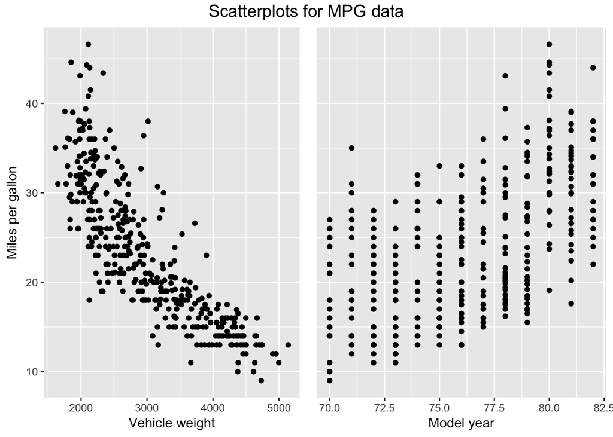

```r
par(.pardefault)
p1<-ggplot(auto, aes(weight, mpg)) +
  geom_point() +
  labs(y = "Miles per gallon",
       x = "Vehicle weight")
p2<-ggplot(auto, aes(modelyear, mpg)) +
  geom_point() +
  theme(axis.title.y=element_blank(),
        axis.text.y=element_blank(),
        axis.ticks.y=element_blank()) +
  labs(x = "Model year")
grid.arrange(p1,p2,ncol=2,
             top=textGrob("Scatterplots for MPG data",
                          gp=gpar(fontsize=14,font=8)))
```

## Figure 3.15 The Auto MPG data after expanding the categorical Origin column

Note that the row numbering differs between python and R by 1 (python starts row numbering at 0, and R starts at 1).

```r
dummies <- dummyVars(" ~ .", data = auto, fullRank = TRUE)
autoNumeric <- data.frame(predict(dummies, newdata = auto))

kable(tail(autoNumeric,5))
```

|  | mpg | cylinders | displacement | horsepower | weight | acceleration | modelyear | origin.Europe | origin.Asia |
| --- | --- | --- | --- | --- | --- | --- | --- | --- | --- |
| 388 | 27 | 4 | 140 | 86 | 2790 | 15.6 | 82 | 0 | 0 |
| 389 | 44 | 4 | 97 | 52 | 2130 | 24.6 | 82 | 1 | 0 |
| 390 | 32 | 4 | 135 | 84 | 2295 | 11.6 | 82 | 0 | 0 |
| 391 | 28 | 4 | 120 | 79 | 2625 | 18.6 | 82 | 0 | 0 |
| 392 | 31 | 4 | 119 | 82 | 2720 | 19.4 | 82 | 0 | 0 |

## Figure 3.16 Comparing MPG predictions on a held-out testing set to actual values

```r
trainIndex <- createDataPartition(autoNumeric$mpg, p = .8,
                                  list = FALSE,
                                  times = 1)

autoTrain <- autoNumeric[ trainIndex,]
autoTest  <- autoNumeric[-trainIndex,]

lmFit <- train(mpg ~ ., data = autoTrain,
               method = "lm")
lmPred <- predict(lmFit, newdata = autoTest)

rowsInTable <- 1:5
kable(data.frame("Origin.Europe" = autoTest$origin.Europe[rowsInTable],
                 "Origin.Asia" = autoTest$origin.Asia[rowsInTable],
                 "MPG" = autoTest$mpg[rowsInTable],
                 "Predicted MPG" = lmPred[rowsInTable]))
```

|  | Origin.Europe | Origin.Asia | MPG | Predicted.MPG |
| --- | --- | --- | --- | --- |
| 1 | 0 | 0 | 18 | 14.89092 |
| 4 | 0 | 0 | 16 | 14.92356 |
| 6 | 0 | 0 | 15 | 10.74239 |
| 7 | 0 | 0 | 14 | 10.74370 |
| 10 | 0 | 0 | 15 | 13.14265 |

## Figure 3.17 A scatter plot of the actual versus predicted values on the held-out test set. The diagonal line shows the perfect regressor. The closer all of the predictions are to this line, the better the model.

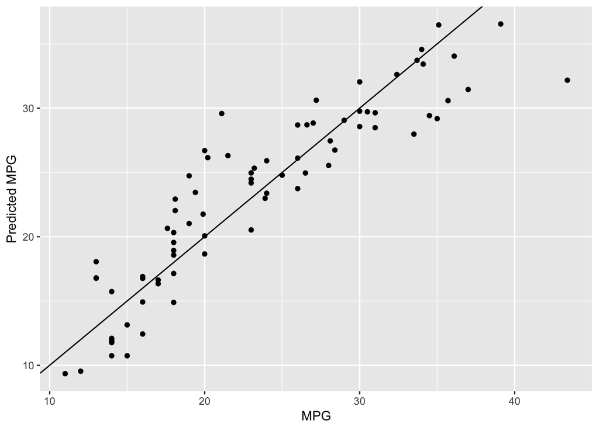

```r
ggplot(autoTest, aes(x=mpg, y=lmPred)) +
  geom_point() +
  geom_abline(slope = 1, intercept = 0) +
  labs(x="MPG", y="Predicted MPG")
```

## Figure 3.18 Table of actual versus predicted MPG values for the nonlinear random forest regression model

```r
rfFit <- train(mpg ~ ., data = autoTrain,
               method = "rf")
rfPred <- predict(rfFit, newdata = autoTest)

kable(data.frame("Origin.Europe" = autoTest$origin.Europe[rowsInTable],
                 "Origin.Asia" = autoTest$origin.Asia[rowsInTable],
                 "MPG" = autoTest$mpg[rowsInTable],
                 "Predicted MPG" = rfPred[rowsInTable]))
```

|  | Origin.Europe | Origin.Asia | MPG | Predicted.MPG |
| --- | --- | --- | --- | --- |
| 1 | 0 | 0 | 18 | 15.80731 |
| 4 | 0 | 0 | 16 | 16.32332 |
| 6 | 0 | 0 | 15 | 13.44830 |
| 7 | 0 | 0 | 14 | 13.53114 |
| 10 | 0 | 0 | 15 | 13.77313 |

## Figure 3.19 Comparison of MPG data versus predicted values for the nonlinear random forest regression model

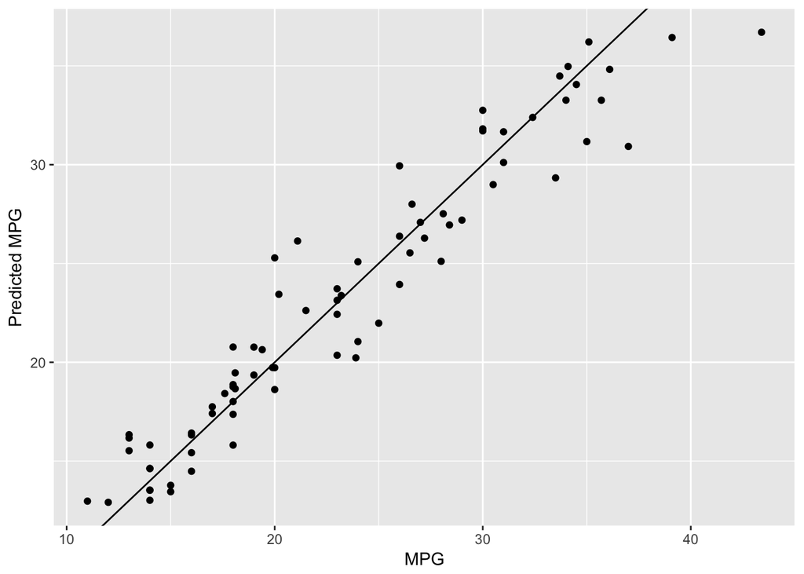

```r
ggplot(autoTest, aes(x=mpg, y=rfPred)) +
  geom_point() +
  geom_abline(slope = 1, intercept = 0) +
  labs(x="MPG", y="Predicted MPG")
```